# Bioestadística con R

## Clase 1: Introducción a R

## Interfaz

R Studio cuenta con **4 ventanas esenciales:**

- La *consola*.
- Los *scripts*.
- El *Envirnoment* y el *History*.
- Los *Files*, *Packages*, *Plots* y *Help*.

También podemos modificar la apariencia y la fuente de nuestro RStudio en la ventana *Global Options.*

## Creando nuestro primer proyecto

Elegimos *New Directory* para crear una nueva carpeta para nuestro directorio.

Se recomienda **no dejar espacios** en los nombres de nuestros archivos.

Una vez creado nuestro nuevo proyecto, podemos crear un nuevo script tecleando Ctrl + Shift + N.

## Directorio de trabajo

Para esto utilizamos la función **getwd().**

```r
getwd()
```

```
## [1] "O:/Tesis/R/Webpage/imalejandrorg.github.io/Curso_R_basico/Presentaciones/Clase-01"
```

## Directorio de trabajo

Para cambiar el directorio de trabajo utilizamos la función **setwd()** seguido de la nueva dirección que queremos establecer.

```r
setwd("O:/Documentos/R_Basico")
getwd()
```

```
## [1] "O:/Documentos/R_Basico"
```

## Objetos y variables

- **Vector:** Es uno de los elementos básicos. Existen distintos de vectores, los cuales pueden ser: lógicos, integers, caracteres y complejos.
- **Lista:** Son objetos que contienen distintos elementos que pueden incluir strings, números, vectores e incluso listas anidadas, así como matrices y o funciones como elementos.
- **Matriz:** Objetos arreglados en un espacio bidimensional. Un requisito es que contengan elementos del mismo tipo. Usualmente las usamos para realizar operaciones matemáticas.
- **Array:** Para almacenar datos en más de dos dimensiones.
- **Factor:** Son objetos que se utilizan para para categorizar y almacenar datos en ciertos niveles. Pueden ser strings o integers. Son usados frecuentemente en análisis estadísticos.
- **Dataframe:** Es una estructuración de datos en dos dimensiones, donde cada columna consiste del valor de una variable y cada fila consiste de un conjunto de valores de las columnas.

## Objetos y variables

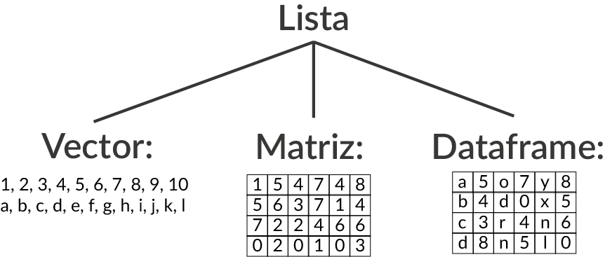

## Instalar paquetes

Los **paquetes** incluyen funciones escritas por otras personas de los cuales podemos hacer uso.

**install.package()**

Para llamar a un paquete…

```r
library(vegan)
```

## Instalar paquetes

Personalmente prefiero instalar los paquetes desde la ventana de *Packages.*

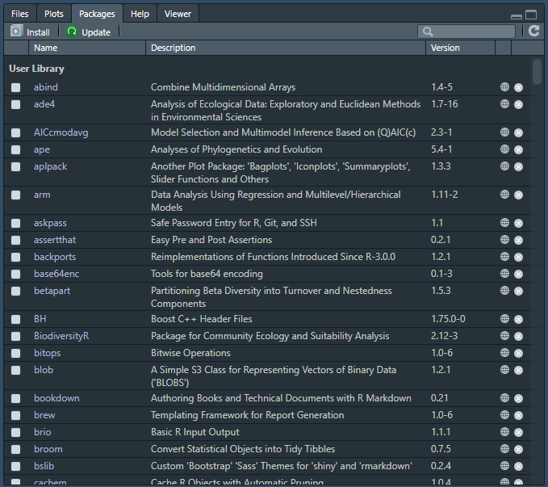

## Importar datos

Importaremos los datos de Palacio et al. (2020). Una base de datos de aves del capítulo 6.

**Descargar:** [“Aves.txt”](https://fundacionazara.org.ar/img/libros/analisis-multivariado-para-datos-biologicos/Aves.txt)

```r
Aves <- read.table("O:/Tesis/R/Webpage/imalejandrorg.github.io/Curso_R_basico/Curso_R_basico/Aves.txt",
                   header = TRUE)
View(Aves)
```

## Importar datos

| sitio | estacion | ambiente | agebad | amabra | rupmag | spimag | chlluc | colmel | patpic | cycguj | elapar | furruf | geoaeq | ictcay | lepang | mimsat | molbon | myimac | myimon | pacpol | phastr | pitsul | poldum | poomel | rossoc | sicfla | siclut | spocae | synspi | … |
| --- | --- | --- | --- | --- | --- | --- | --- | --- | --- | --- | --- | --- | --- | --- | --- | --- | --- | --- | --- | --- | --- | --- | --- | --- | --- | --- | --- | --- | --- | --- |
| 2 | inv | bosque | 1 | 0 | 0 | 0 | 0 | 2 | 2 | 1 | 0 | 6 | 1 | 1 | 1 | 1 | 0 | 0 | 0 | 0 | 0 | 2 | 0 | 0 | 1 | 0 | 0 | 0 | 0 | … |
| 2 | oto | bosque | 1 | 0 | 1 | 0 | 0 | 3 | 2 | 0 | 0 | 2 | 0 | 0 | 2 | 5 | 0 | 0 | 0 | 0 | 0 | 3 | 0 | 0 | 1 | 0 | 0 | 0 | 0 | … |
| 2 | pri | bosque | 2 | 0 | 0 | 0 | 0 | 0 | 0 | 0 | 0 | 0 | 0 | 0 | 0 | 0 | 0 | 0 | 0 | 2 | 0 | 1 | 0 | 0 | 0 | 0 | 0 | 0 | 0 | … |
| 2 | ver | bosque | 1 | 0 | 0 | 0 | 0 | 3 | 0 | 0 | 1 | 6 | 0 | 0 | 4 | 0 | 0 | 0 | 0 | 1 | 1 | 6 | 0 | 0 | 0 | 0 | 0 | 0 | 0 | … |
| 3 | inv | arbustal | 1 | 0 | 0 | 0 | 0 | 1 | 0 | 0 | 0 | 6 | 0 | 0 | 1 | 0 | 3 | 0 | 0 | 0 | 1 | 2 | 0 | 0 | 3 | 0 | 0 | 0 | 2 | … |
| 3 | oto | arbustal | 0 | 0 | 0 | 0 | 0 | 0 | 0 | 0 | 0 | 8 | 0 | 0 | 2 | 0 | 0 | 0 | 0 | 0 | 1 | 3 | 0 | 0 | 3 | 0 | 0 | 0 | 0 | … |
| 3 | pri | arbustal | 0 | 0 | 0 | 0 | 0 | 2 | 1 | 0 | 0 | 1 | 1 | 0 | 0 | 0 | 0 | 0 | 0 | 0 | 0 | 0 | 0 | 0 | 0 | 0 | 0 | 0 | 0 | … |
| 3 | ver | arbustal | 3 | 0 | 0 | 0 | 2 | 0 | 0 | 0 | 0 | 2 | 0 | 0 | 0 | 0 | 0 | 0 | 0 | 0 | 0 | 1 | 0 | 0 | 0 | 0 | 0 | 1 | 0 | … |
| 4 | inv | arbustal | 8 | 0 | 0 | 10 | 0 | 0 | 0 | 0 | 0 | 1 | 2 | 2 | 1 | 0 | 1 | 0 | 14 | 0 | 2 | 1 | 0 | 2 | 0 | 0 | 0 | 0 | 1 | … |
| 4 | oto | arbustal | 0 | 0 | 0 | 0 | 0 | 1 | 0 | 0 | 0 | 1 | 0 | 1 | 0 | 0 | 0 | 0 | 0 | 0 | 0 | 1 | 3 | 3 | 0 | 0 | 0 | 0 | 0 | … |
| 4 | pri | arbustal | 0 | 0 | 0 | 0 | 0 | 0 | 0 | 0 | 0 | 0 | 3 | 0 | 0 | 0 | 2 | 0 | 0 | 0 | 1 | 2 | 0 | 0 | 0 | 0 | 4 | 0 | 0 | … |
| 4 | ver | arbustal | 1 | 0 | 0 | 0 | 0 | 0 | 0 | 0 | 0 | 3 | 1 | 0 | 0 | 0 | 0 | 1 | 0 | 0 | 1 | 2 | 0 | 0 | 0 | 0 | 0 | 3 | 2 | … |
| 5 | inv | bosque | 0 | 0 | 0 | 0 | 0 | 3 | 2 | 3 | 0 | 4 | 1 | 2 | 1 | 0 | 1 | 0 | 0 | 0 | 0 | 9 | 0 | 0 | 0 | 0 | 0 | 0 | 0 | … |
| 5 | oto | bosque | 37 | 0 | 2 | 0 | 0 | 2 | 2 | 0 | 0 | 2 | 0 | 0 | 1 | 0 | 0 | 0 | 0 | 0 | 0 | 3 | 2 | 0 | 0 | 0 | 0 | 0 | 0 | … |
| 5 | pri | bosque | 0 | 0 | 0 | 1 | 0 | 0 | 0 | 0 | 6 | 0 | 0 | 0 | 0 | 0 | 0 | 0 | 0 | 0 | 0 | 2 | 0 | 0 | 0 | 0 | 0 | 0 | 0 | … |
| 5 | ver | bosque | 10 | 0 | 2 | 0 | 0 | 2 | 0 | 2 | 2 | 0 | 0 | 0 | 0 | 0 | 0 | 1 | 0 | 3 | 0 | 5 | 0 | 0 | 0 | 0 | 0 | 0 | 1 | … |
| 6 | inv | bosque | 0 | 0 | 5 | 0 | 0 | 1 | 2 | 1 | 0 | 4 | 0 | 0 | 1 | 0 | 0 | 0 | 0 | 0 | 0 | 8 | 2 | 0 | 0 | 0 | 0 | 0 | 0 | … |
| 6 | oto | bosque | 0 | 1 | 4 | 0 | 0 | 0 | 2 | 0 | 0 | 3 | 0 | 0 | 1 | 0 | 0 | 0 | 0 | 0 | 0 | 5 | 0 | 0 | 0 | 0 | 0 | 0 | 0 | … |
| 6 | pri | bosque | 2 | 0 | 2 | 0 | 0 | 0 | 0 | 1 | 4 | 0 | 0 | 0 | 0 | 0 | 0 | 0 | 0 | 0 | 0 | 5 | 0 | 0 | 0 | 0 | 0 | 0 | 0 | … |
| 6 | ver | bosque | 0 | 4 | 3 | 0 | 1 | 1 | 0 | 0 | 2 | 1 | 0 | 0 | 1 | 0 | 0 | 4 | 0 | 4 | 0 | 1 | 0 | 0 | 0 | 0 | 0 | 0 | 0 | … |
| 7 | inv | bosque | 0 | 0 | 1 | 0 | 1 | 0 | 6 | 0 | 2 | 0 | 0 | 1 | 0 | 0 | 0 | 0 | 0 | 0 | 0 | 4 | 0 | 0 | 0 | 0 | 0 | 0 | 0 | … |
| 7 | oto | bosque | 0 | 0 | 0 | 0 | 0 | 1 | 2 | 1 | 0 | 2 | 0 | 2 | 0 | 1 | 0 | 0 | 0 | 0 | 0 | 1 | 0 | 0 | 0 | 0 | 0 | 0 | 0 | … |
| 7 | pri | bosque | 0 | 0 | 1 | 0 | 0 | 0 | 0 | 0 | 3 | 0 | 1 | 0 | 0 | 0 | 0 | 0 | 0 | 0 | 0 | 2 | 0 | 0 | 0 | 0 | 0 | 0 | 0 | … |
| 7 | ver | bosque | 1 | 0 | 0 | 0 | 0 | 1 | 7 | 0 | 3 | 2 | 0 | 0 | 0 | 0 | 0 | 0 | 0 | 0 | 0 | 2 | 0 | 0 | 0 | 0 | 0 | 0 | 0 | … |
| 8 | inv | arbustal | 0 | 0 | 0 | 0 | 0 | 0 | 0 | 2 | 0 | 1 | 1 | 0 | 0 | 2 | 2 | 0 | 0 | 0 | 0 | 3 | 0 | 0 | 1 | 2 | 2 | 0 | 0 | … |
| 8 | oto | arbustal | 0 | 0 | 0 | 1 | 0 | 0 | 0 | 0 | 0 | 1 | 0 | 0 | 0 | 0 | 0 | 0 | 0 | 0 | 0 | 0 | 0 | 0 | 0 | 0 | 0 | 0 | 0 | … |
| 8 | pri | arbustal | 0 | 0 | 0 | 0 | 0 | 0 | 0 | 0 | 1 | 0 | 1 | 0 | 0 | 0 | 0 | 0 | 0 | 0 | 0 | 4 | 0 | 0 | 0 | 4 | 2 | 1 | 0 | … |
| 8 | ver | arbustal | 0 | 0 | 0 | 0 | 1 | 0 | 0 | 0 | 2 | 2 | 0 | 0 | 1 | 0 | 0 | 0 | 0 | 0 | 0 | 2 | 1 | 0 | 0 | 0 | 0 | 7 | 1 | … |
| 9 | inv | arbustal | 0 | 0 | 0 | 0 | 0 | 4 | 0 | 0 | 0 | 0 | 0 | 0 | 0 | 0 | 1 | 0 | 3 | 0 | 0 | 0 | 1 | 1 | 0 | 0 | 4 | 0 | 0 | … |
| 9 | oto | arbustal | 0 | 0 | 0 | 0 | 0 | 0 | 0 | 0 | 0 | 2 | 0 | 0 | 0 | 0 | 0 | 0 | 0 | 0 | 0 | 1 | 0 | 0 | 0 | 0 | 0 | 0 | 0 | … |
| 9 | pri | arbustal | 0 | 0 | 0 | 0 | 0 | 0 | 0 | 0 | 0 | 0 | 3 | 0 | 0 | 0 | 1 | 0 | 0 | 0 | 0 | 2 | 0 | 0 | 0 | 0 | 5 | 0 | 0 | … |
| 9 | ver | arbustal | 3 | 0 | 0 | 0 | 0 | 0 | 0 | 0 | 0 | 2 | 0 | 0 | 0 | 0 | 0 | 0 | 0 | 0 | 1 | 0 | 0 | 0 | 0 | 3 | 11 | 6 | 1 | … |
| 10 | inv | arbustal | 0 | 0 | 0 | 1 | 0 | 0 | 0 | 0 | 0 | 0 | 1 | 0 | 2 | 0 | 8 | 0 | 0 | 0 | 2 | 4 | 0 | 0 | 0 | 0 | 3 | 0 | 1 | … |
| 10 | oto | arbustal | 0 | 0 | 0 | 0 | 0 | 1 | 1 | 0 | 0 | 1 | 0 | 0 | 0 | 0 | 0 | 0 | 0 | 0 | 0 | 3 | 0 | 0 | 1 | 0 | 0 | 0 | 3 | … |
| 10 | pri | arbustal | 0 | 0 | 0 | 0 | 0 | 0 | 0 | 0 | 0 | 2 | 3 | 0 | 0 | 0 | 0 | 0 | 0 | 0 | 0 | 0 | 0 | 0 | 0 | 0 | 0 | 0 | 0 | … |
| 10 | ver | arbustal | 1 | 0 | 0 | 0 | 0 | 1 | 0 | 0 | 0 | 7 | 2 | 0 | 0 | 0 | 0 | 0 | 0 | 0 | 0 | 2 | 0 | 0 | 0 | 0 | 3 | 8 | 1 | … |

## Importar datos

Para otros formatos utilizamos:

- **.csv:** read.csv()
- **.xlsx:** read_excel(), del paquete readxl.

```r
Aves_csv <- read.csv("O:/Tesis/R/Webpage/imalejandrorg.github.io/Curso_R_basico/Curso_R_basico/Aves.csv",
                     header = TRUE)

library(readxl)
Aves_xlsx <- read_excel("O:/Tesis/R/Webpage/imalejandrorg.github.io/Curso_R_basico/Curso_R_basico/Aves.xlsx")
```

## Comentarios

Los comentarios nos permiten recordar la utilidad de algunas líneas de código, funciones o argumentos en particular, solo basta agregarlos a nuestro script tecleando el símbolo de “gato” o “hashtag” (#).

```r
# Creamos una variable que contenga la suma de 5 + 5.
x <- 5 + 5
```

## Exportar datos

Aunque trabajando con **R Markdown** casi nunca exportamos datos, podemos hacer esto…

```r
#Filtramos nuestro archivo para tener solo las abundancias.
Abun <- Aves[,4:35]

#Exportamos nuestro archivo en formato .csv
write.table(Abun, file = "Abundancias.csv", sep = ",", row.names = FALSE)
```

Si no se especifica una ruta, se guardará el archivo en el directorio de trabajo.

## Pedir ayuda

Cuando no sepamos cómo fuciona exactamente algo, podemos pedir ayuda agregando el símbolo de pregunta ?.

```r
?mean()
```